# Mini-Project 2: Forecasting US Energy Consumption

Author

You are asked to predict the monthly US residential energy consumption for the next 2 years for the ‘Short-Term Energy Outlook’ using data from the US Department of Energy.

## IMPORT

The US Department of Energy collects an impressive amount of data to support the energy industries. For this assignment use the monthly total energy consumed by the US residential sector. The webpage

https://www.eia.gov/totalenergy/data/browser/index.php?tbl=T02.02

contains monthly web tables, but an easier approach to getting the data into R uses the result of the ‘Download’ button to read the source data from the source CSV file.

```r
energy <- read_csv("https://www.eia.gov/totalenergy/data/browser/csv.php?tbl=T02.02",
# names in first row, but the names aren't meaningful
                   col_names = c("MSN","Time","Res_Energy","label1","label2","label3"),
                   skip = 1) |>
  mutate(Res_Energy = parse_number(Res_Energy),
         Time = ym(Time))
```

## TIDY

```r
tail(energy)
```

```
# A tibble: 6 × 6
  MSN     Time       Res_Energy label1 label2                             label3
  <chr>   <date>          <dbl>  <dbl> <chr>                              <chr>
1 TERCBUS 2022-11-01      1729.     13 Total Energy Consumed by the Resi… Trill…
2 TERCBUS 2022-12-01      2394.     13 Total Energy Consumed by the Resi… Trill…
3 TERCBUS NA             21807.     13 Total Energy Consumed by the Resi… Trill…
4 TERCBUS 2023-01-01      2311.     13 Total Energy Consumed by the Resi… Trill…
5 TERCBUS 2023-02-01      1980.     13 Total Energy Consumed by the Resi… Trill…
6 TERCBUS 2023-03-01      1920.     13 Total Energy Consumed by the Resi… Trill…
```

## TRANSFORM

Code should

- filter to the data in rows where `MSN` is `TERCBUS` (Total Energy Consumed by the Residential Sector in trillion Btu),
- filter to current data (after 1991),
- only include the columns `Time` and `Res_Energy` columns, and
- remove the annual total rows (`Time` is missing / `NA`).

```r
energy <- energy |>
# subset to TERCBUS Total Energy Consumed by the Residential Sector
  filter(MSN == "TERCBUS") |>
# subset to "since the 90's"
  filter(Time >= ymd("1991-1-1")) |>
# remove annual total rows (Time is NA)
  na.omit() |>
# keep just the Time and Res_Energy columns
  select("Time", "Res_Energy")

# take a look
tail(energy)
```

```
# A tibble: 6 × 2
  Time       Res_Energy
  <date>          <dbl>
1 2022-10-01      1350.
2 2022-11-01      1729.
3 2022-12-01      2394.
4 2023-01-01      2311.
5 2023-02-01      1980.
6 2023-03-01      1920.
```

## VISUALIZE

Plot the time series for US residential energy consumption (in trillion Btu).

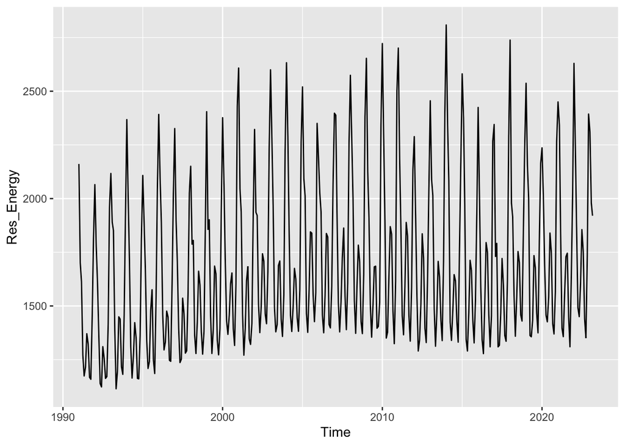

```r
ggplot(energy, aes(x = Time, y = Res_Energy)) +
  #geom_"___"() +
  #geom_"___"() +
  geom_line() +
  labs(
    #title = "___",
    #x = "___",
    #y = "___",
    #___
    )
```

## MODEL

Fit an ARIMA$(1, 1, 1) \times (1, 1, 1)_{12}$ model and report the parameter estimates and standard errors.

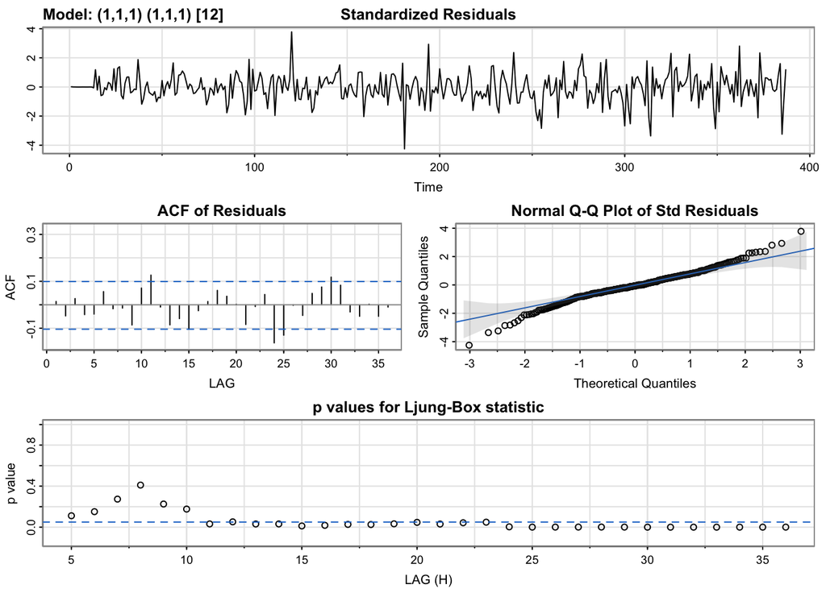

```r
energy_out <- sarima(energy$Res_Energy, 1,1,1, 1,1,1, 12)
```

```r
# table of estimates and se
energy_out$ttable
```

```
     Estimate     SE  t.value p.value
ar1    0.4215 0.0501   8.4176  0.0000
ma1   -0.9592 0.0148 -64.8327  0.0000
sar1   0.0559 0.0613   0.9118  0.3625
sma1  -0.8817 0.0377 -23.3985  0.0000
```

Forecast the US residential energy consumption for the next 2 years. Report a table of predictions and 95% prediction intervals.

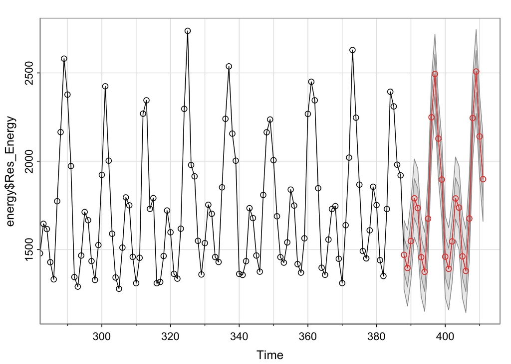

```r
#  "next two years"
energy_forecast <- data.frame(Time = max(energy$Time) + months(1 : 24))
energy_yhat <- sarima.for(energy$Res_Energy , n.ahead = 24, 1,1,1, 1,1,1, 12)
```

```r
# table of forecasts and uncertainty
energy_forecast$pred <- energy_yhat$pred
energy_forecast$L <- energy_yhat$pred - 2 * energy_yhat$se
energy_forecast$U <- energy_yhat$pred + 2 * energy_yhat$se

energy_forecast
```

```
         Time     pred        L        U
1  2023-04-01 1470.100 1274.877 1665.323
2  2023-05-01 1395.704 1180.627 1610.781
3  2023-06-01 1547.993 1328.050 1767.936
4  2023-07-01 1790.262 1568.625 2011.900
5  2023-08-01 1735.191 1512.698 1957.684
6  2023-09-01 1456.982 1233.902 1680.061
7  2023-10-01 1374.093 1150.525 1597.662
8  2023-11-01 1675.028 1451.009 1899.047
9  2023-12-01 2249.062 2024.610 2473.515
10 2024-01-01 2493.880 2269.001 2718.758
11 2024-02-01 2128.268 1902.967 2353.568
12 2024-03-01 1896.307 1670.586 2122.029
13 2024-04-01 1459.778 1229.054 1690.502
14 2024-05-01 1391.005 1158.404 1623.606
15 2024-06-01 1546.081 1312.462 1779.699
16 2024-07-01 1789.436 1555.084 2023.788
17 2024-08-01 1737.626 1502.647 1972.605
18 2024-09-01 1461.553 1225.991 1697.116
19 2024-10-01 1379.158 1143.030 1615.287
20 2024-11-01 1675.745 1439.059 1912.431
21 2024-12-01 2244.761 2007.521 2482.000
22 2025-01-01 2507.916 2270.126 2745.705
23 2025-02-01 2140.319 1901.981 2378.658
24 2025-03-01 1898.762 1659.876 2137.647
```

## COMMUNICATE

Does it appear there is a monthly pattern? If so, explain the possible business/economic ‘cause’ for this effect.